# TIL: Perfect Fit

Oh boy…

Vincent Warmerdam koaning.io  
2022-04-21

This TIL is mostly meant as a reminder that I shouldn’t forget [this tweet](https://twitter.com/rasbt/status/1516833338316963840) by Sebiastian Raschka. Credits should go to him for sharing, I just want to make sure that I don’t forget it.

Here’s the story, there’s a [paper](https://arxiv.org/pdf/2204.07953v1.pdf).

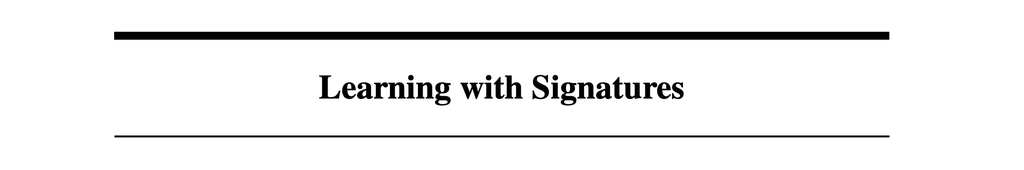

This paper comes with a pretty big claim.

> We develop a closed-form equation to compute probably good optimal scale factors. Classification is performed at the CPU level orders of magnitude faster than other methods. We report results on AFHQ dataset, Four Shapes, MNIST and CIFAR10 achieving 100% accuracy on all tasks.

Here’s the thing though: CIFAR10 and MNIST contain label errors. So how is 100% even possible?

It seems, unfortunately, that there’s a [data leak](https://github.com/decurtoydiaz/learning_with_signatures/issues/1#issuecomment-1103803777) in the code that helps explain what happened.

Ouch.

The point from my perspective isn’t that we should point fingers at people suggesting that they didn’t do their job well. Sure, they should have know better, but it also feels like an error that happens to most people doing benchmarks. It seems more meaningful to remind ourselves that it’s too easy to fall into a trap of algorithmic optimism.

Put in other words, it’s easy to be [optimal on paper and broken in reality](https://www.youtube.com/watch?v=lJKPiOf_o8k&ab_channel=PyData).